# 2018 Bay Wheels Ride Data Exploration and Visualization

### By Elham Daha

- Introduction
- Preliminary Wrangling
- Univariate Exploration
- Bivariate Explorationn
- Multivariate Exploration
- Summary
- Sources

## Introduction

Bay Wheels (previously known as Ford GoBike) is a regional public bike sharing system in the San Francisco Bay Area, California. Bay Wheels is the first regional and large-scale bicycle sharing system deployed in California and on the West Coast of the United States with nearly 500,000 rides since the launch in 2017 and had about 10,000 annual subscribers as of January 2018.

Ford GoBike, like other bike share systems, consists of a fleet of specially designed, sturdy and durable bikes that are locked into a network of docking stations throughout the city. The bikes can be unlocked from one station and returned to any other station in the system, making them ideal for one-way trips. People use bike share to commute to work or school, run errands, get to appointments or social engagements and more. It's a fun, convenient and affordable way to get around.

The bikes are available for use 24 hours/day, 7 days/week, 365 days/year and riders have access to all bikes in the network when they become a member or purchase a pass.

The dataset used for this exploratory analysis consists of monthly individual trip data from January 2018 to December 2018 in CSV format covering the greater San Francisco Bay area, also available here.

## Preliminary Wrangling

```python
# import all packages and set plots to be embedded inline
import numpy as np
import pandas as pd
import matplotlib.pyplot as plt
%matplotlib inline
import seaborn as sb
import glob
import os
import datetime
```

### Gathering

#### Specifying folder path where all the files from 2018 are stored

```python
path =r'C:\Users\edaha\Desktop\Courses\DataAnalyst\Session5\Project5\Data'

files = glob.glob(os.path.join(path, "*.csv"))
```

#### Reading the content from all the files and concatenating them into a single fil

```python
df = pd.concat((pd.read_csv(f) for f in files), ignore_index = True)

df.to_csv('master_file.csv', index=False)
```

```python
df_new = pd.read_csv('master_file.csv')
```

```python
df_new.head()
```

|  | duration_sec | start_time | end_time | start_station_id | start_station_name | start_station_latitude | start_station_longitude | end_station_id | end_station_name | end_station_latitude | end_station_longitude | bike_id | user_type | bike_share_for_all_trip |
| --- | --- | --- | --- | --- | --- | --- | --- | --- | --- | --- | --- | --- | --- | --- |
| 0 | 75284 | 2018-01-31 22:52:35.2390 | 2018-02-01 19:47:19.8240 | 120.0 | Mission Dolores Park | 37.761420 | -122.426435 | 285.0 | Webster St at O'Farrell St | 37.783521 | -122.431158 | 2765 | Subscriber | No |
| 1 | 85422 | 2018-01-31 16:13:34.3510 | 2018-02-01 15:57:17.3100 | 15.0 | San Francisco Ferry Building (Harry Bridges Pl... | 37.795392 | -122.394203 | 15.0 | San Francisco Ferry Building (Harry Bridges Pl... | 37.795392 | -122.394203 | 2815 | Customer | No |
| 2 | 71576 | 2018-01-31 14:23:55.8890 | 2018-02-01 10:16:52.1160 | 304.0 | Jackson St at 5th St | 37.348759 | -121.894798 | 296.0 | 5th St at Virginia St | 37.325998 | -121.877120 | 3039 | Customer | No |
| 3 | 61076 | 2018-01-31 14:53:23.5620 | 2018-02-01 07:51:20.5000 | 75.0 | Market St at Franklin St | 37.773793 | -122.421239 | 47.0 | 4th St at Harrison St | 37.780955 | -122.399749 | 321 | Customer | No |
| 4 | 39966 | 2018-01-31 19:52:24.6670 | 2018-02-01 06:58:31.0530 | 74.0 | Laguna St at Hayes St | 37.776435 | -122.426244 | 19.0 | Post St at Kearny St | 37.788975 | -122.403452 | 617 | Subscriber | No |

```python
df_new.info()
```

```
<class 'pandas.core.frame.DataFrame'>
RangeIndex: 1863721 entries, 0 to 1863720
Data columns (total 14 columns):
 #   Column                   Dtype
---  ------                   -----
 0   duration_sec             int64
 1   start_time               object
 2   end_time                 object
 3   start_station_id         float64
 4   start_station_name       object
 5   start_station_latitude   float64
 6   start_station_longitude  float64
 7   end_station_id           float64
 8   end_station_name         object
 9   end_station_latitude     float64
 10  end_station_longitude    float64
 11  bike_id                  int64
 12  user_type                object
 13  bike_share_for_all_trip  object
dtypes: float64(6), int64(2), object(6)
memory usage: 199.1+ MB
```

```python
df_new.sample(10)
```

|  | duration_sec | start_time | end_time | start_station_id | start_station_name | start_station_latitude | start_station_longitude | end_station_id | end_station_name | end_station_latitude | end_station_longitude | bike_id | user_type | bike_share_for_all_trip |
| --- | --- | --- | --- | --- | --- | --- | --- | --- | --- | --- | --- | --- | --- | --- |
| 1628851 | 535 | 2018-11-22 12:40:19.1670 | 2018-11-22 12:49:14.4400 | 114.0 | Rhode Island St at 17th St | 37.764478 | -122.402570 | 92.0 | Mission Bay Kids Park | 37.772301 | -122.393028 | 2090 | Subscriber | No |
| 69432 | 115 | 2018-01-11 10:07:49.3250 | 2018-01-11 10:09:44.5310 | 311.0 | Paseo De San Antonio at 2nd St | 37.333798 | -121.886943 | 310.0 | San Fernando St at 4th St | 37.335885 | -121.885660 | 1323 | Subscriber | No |
| 1354090 | 371 | 2018-09-08 17:17:18.9230 | 2018-09-08 17:23:30.7750 | 256.0 | Hearst Ave at Euclid Ave | 37.875112 | -122.260553 | 238.0 | MLK Jr Way at University Ave | 37.871719 | -122.273068 | 169 | Subscriber | No |
| 1448680 | 338 | 2018-10-23 20:09:18.2110 | 2018-10-23 20:14:56.2850 | 44.0 | Civic Center/UN Plaza BART Station (Market St ... | 37.781074 | -122.411738 | 59.0 | S Van Ness Ave at Market St | 37.774814 | -122.418954 | 1333 | Subscriber | No |
| 476142 | 680 | 2018-05-25 21:02:57.4680 | 2018-05-25 21:14:18.4210 | 22.0 | Howard St at Beale St | 37.789756 | -122.394643 | 66.0 | 3rd St at Townsend St | 37.778742 | -122.392741 | 3247 | Subscriber | No |
| 1339849 | 883 | 2018-09-11 08:48:31.1060 | 2018-09-11 09:03:14.2430 | 61.0 | Howard St at 8th St | 37.776513 | -122.411306 | 22.0 | Howard St at Beale St | 37.789756 | -122.394643 | 1416 | Subscriber | No |
| 79117 | 1098 | 2018-01-07 15:54:09.6450 | 2018-01-07 16:12:28.5040 | 114.0 | Rhode Island St at 17th St | 37.764478 | -122.402570 | 324.0 | Union Square (Powell St at Post St) | 37.788300 | -122.408531 | 1646 | Subscriber | No |
| 103101 | 304 | 2018-02-27 08:03:06.1550 | 2018-02-27 08:08:11.0680 | 15.0 | San Francisco Ferry Building (Harry Bridges Pl... | 37.795392 | -122.394203 | 21.0 | Montgomery St BART Station (Market St at 2nd St) | 37.789625 | -122.400811 | 86 | Subscriber | No |
| 987474 | 512 | 2018-07-06 15:55:19.8940 | 2018-07-06 16:03:52.2220 | 27.0 | Beale St at Harrison St | 37.788059 | -122.391865 | 30.0 | San Francisco Caltrain (Townsend St at 4th St) | 37.776598 | -122.395282 | 3887 | Subscriber | No |
| 1201036 | 999 | 2018-08-02 09:43:31.8910 | 2018-08-02 10:00:11.4960 | 355.0 | 23rd St at Tennessee St | 37.755367 | -122.388795 | 36.0 | Folsom St at 3rd St | 37.783830 | -122.398870 | 2443 | Customer | No |

```python
df_new.shape
```

```
(1863721, 14)
```

```python
df.start_time = pd.to_datetime(df.start_time)
df.end_time = pd.to_datetime(df.end_time)
```

```python
df.info()
```

```
<class 'pandas.core.frame.DataFrame'>
RangeIndex: 1863721 entries, 0 to 1863720
Data columns (total 14 columns):
 #   Column                   Dtype
---  ------                   -----
 0   duration_sec             int64
 1   start_time               datetime64[ns]
 2   end_time                 datetime64[ns]
 3   start_station_id         float64
 4   start_station_name       object
 5   start_station_latitude   float64
 6   start_station_longitude  float64
 7   end_station_id           float64
 8   end_station_name         object
 9   end_station_latitude     float64
 10  end_station_longitude    float64
 11  bike_id                  int64
 12  user_type                object
 13  bike_share_for_all_trip  object
dtypes: datetime64[ns](2), float64(6), int64(2), object(4)
memory usage: 199.1+ MB
```

```python
# Let's also get some additional description for stats figures
df_new.describe()
```

|  | duration_sec | start_station_id | start_station_latitude | start_station_longitude | end_station_id | end_station_latitude | end_station_longitude | bike_id |
| --- | --- | --- | --- | --- | --- | --- | --- | --- |
| count | 1.863721e+06 | 1.851950e+06 | 1.863721e+06 | 1.863721e+06 | 1.851950e+06 | 1.863721e+06 | 1.863721e+06 | 1.863721e+06 |
| mean | 8.573026e+02 | 1.196744e+02 | 3.776678e+01 | -1.223492e+02 | 1.181730e+02 | 3.776690e+01 | -1.223487e+02 | 2.296851e+03 |
| std | 2.370379e+03 | 1.003976e+02 | 1.057689e-01 | 1.654634e-01 | 1.004403e+02 | 1.056483e-01 | 1.650597e-01 | 1.287733e+03 |
| min | 6.100000e+01 | 3.000000e+00 | 3.726331e+01 | -1.224737e+02 | 3.000000e+00 | 3.726331e+01 | -1.224737e+02 | 1.100000e+01 |
| 25% | 3.500000e+02 | 3.300000e+01 | 3.777106e+01 | -1.224114e+02 | 3.000000e+01 | 3.777106e+01 | -1.224094e+02 | 1.225000e+03 |
| 50% | 5.560000e+02 | 8.900000e+01 | 3.778107e+01 | -1.223974e+02 | 8.800000e+01 | 3.778127e+01 | -1.223971e+02 | 2.338000e+03 |
| 75% | 8.720000e+02 | 1.860000e+02 | 3.779625e+01 | -1.222865e+02 | 1.830000e+02 | 3.779728e+01 | -1.222894e+02 | 3.333000e+03 |
| max | 8.636600e+04 | 3.810000e+02 | 4.551000e+01 | -7.357000e+01 | 3.810000e+02 | 4.551000e+01 | -7.357000e+01 | 6.234000e+03 |

```python
# Any duplicates?
df_new.duplicated().sum()
# No duplicates here - that was straightforward
```

```
0
```

```python
# What about NaN values?
df_new.isna().sum()
# It looks like some of the starting and ending values are NaN.
```

```
duration_sec                   0
start_time                     0
end_time                       0
start_station_id           11771
start_station_name         11771
start_station_latitude         0
start_station_longitude        0
end_station_id             11771
end_station_name           11771
end_station_latitude           0
end_station_longitude          0
bike_id                        0
user_type                      0
bike_share_for_all_trip        0
dtype: int64
```

```python
#Are there duplicated bike ids?
df_new[df_new.bike_id.duplicated()]
```

|  | duration_sec | start_time | end_time | start_station_id | start_station_name | start_station_latitude | start_station_longitude | end_station_id | end_station_name | end_station_latitude | end_station_longitude | bike_id | user_type | bike_share_for_all_trip |
| --- | --- | --- | --- | --- | --- | --- | --- | --- | --- | --- | --- | --- | --- | --- |
| 36 | 196 | 2018-01-31 22:55:25.4130 | 2018-01-31 22:58:42.1420 | 93.0 | 4th St at Mission Bay Blvd S | 37.770407 | -122.391198 | 81.0 | Berry St at 4th St | 37.775880 | -122.393170 | 1403 | Subscriber | No |
| 53 | 520 | 2018-01-31 22:32:52.9330 | 2018-01-31 22:41:33.1470 | 146.0 | 30th St at San Jose Ave | 37.742314 | -122.423181 | 98.0 | Valencia St at 16th St | 37.765052 | -122.421866 | 1278 | Subscriber | No |
| 61 | 612 | 2018-01-31 22:21:06.9690 | 2018-01-31 22:31:18.9740 | 284.0 | Yerba Buena Center for the Arts (Howard St at ... | 37.784872 | -122.400876 | 99.0 | Folsom St at 15th St | 37.767037 | -122.415442 | 3379 | Subscriber | No |
| 86 | 12167 | 2018-01-31 18:45:53.0990 | 2018-01-31 22:08:40.1500 | 64.0 | 5th St at Brannan St | 37.776754 | -122.399018 | 58.0 | Market St at 10th St | 37.776619 | -122.417385 | 3483 | Customer | No |
| 92 | 2440 | 2018-01-31 21:23:58.0530 | 2018-01-31 22:04:38.7510 | 324.0 | Union Square (Powell St at Post St) | 37.788300 | -122.408531 | 41.0 | Golden Gate Ave at Polk St | 37.781270 | -122.418740 | 236 | Customer | No |
| ... | ... | ... | ... | ... | ... | ... | ... | ... | ... | ... | ... | ... | ... | ... |
| 1863716 | 473 | 2018-12-01 00:11:54.8110 | 2018-12-01 00:19:48.5470 | 345.0 | Hubbell St at 16th St | 37.766474 | -122.398295 | 81.0 | Berry St at 4th St | 37.775880 | -122.393170 | 3035 | Subscriber | No |
| 1863717 | 841 | 2018-12-01 00:02:48.7260 | 2018-12-01 00:16:49.7660 | 10.0 | Washington St at Kearny St | 37.795393 | -122.404770 | 58.0 | Market St at 10th St | 37.776619 | -122.417385 | 2034 | Subscriber | No |
| 1863718 | 260 | 2018-12-01 00:05:27.6150 | 2018-12-01 00:09:47.9560 | 245.0 | Downtown Berkeley BART | 37.870139 | -122.268422 | 255.0 | Virginia St at Shattuck Ave | 37.876573 | -122.269528 | 2243 | Subscriber | No |
| 1863719 | 292 | 2018-12-01 00:03:06.5490 | 2018-12-01 00:07:59.0800 | 93.0 | 4th St at Mission Bay Blvd S | 37.770407 | -122.391198 | 126.0 | Esprit Park | 37.761634 | -122.390648 | 545 | Subscriber | No |
| 1863720 | 150 | 2018-12-01 00:03:05.7420 | 2018-12-01 00:05:36.0260 | 107.0 | 17th St at Dolores St | 37.763015 | -122.426497 | 119.0 | 18th St at Noe St | 37.761047 | -122.432642 | 4319 | Subscriber | No |

1858667 rows × 14 columns

```python
df_new.user_type.value_counts()
```

```
Subscriber    1583554
Customer       280167
Name: user_type, dtype: int64
```

### Cleaning

Before assessing the data to draw conclusions, there are some quality issues (this dataset is tidy) that need to be cleaned (from left to right):

- There are missing values throughout the dataset (start_station_id, start_station_name, end_station_id, end_station_name)
- Start/end times are not in the timestamp format
- The following columns are not in object format:
  - start_station_id
  - end_station_id
  - bike_id
  - There are catogorical columns.

```python
# Save the original data set and save as a new, cleaned version while I clean things up
df_cleaned = df_new.copy()
```

#### Define: Converting several of the columns to the appropriate data type:

- Starting and ending times to the timestamp format
- User type and bike share for all to category format
- Bike ID, start station ID, and end station ID to object format

```python
# Changing the format to datetime
df_cleaned.start_time = pd.to_datetime(df_cleaned.start_time)
df_cleaned.end_time = pd.to_datetime(df_cleaned.end_time)
```

```python
# Changing the user_type, and bike_share_for_all_trip to category format
df_cleaned.user_type  = df_cleaned.user_type.astype('category')
df_cleaned.bike_share_for_all_trip = df_cleaned.bike_share_for_all_trip.astype('category')
```

```python
# Changing the bike_id, start_station_id, and end_station_id to object
df_cleaned.bike_id = df_cleaned.bike_id.astype(str)
df_cleaned.start_station_id = df_cleaned.start_station_id.astype(str)
df_cleaned.end_station_id = df_cleaned.end_station_id.astype(str)
```

```python
df_cleaned.info(null_counts = True)
```

```
<class 'pandas.core.frame.DataFrame'>
RangeIndex: 1863721 entries, 0 to 1863720
Data columns (total 14 columns):
 #   Column                   Non-Null Count    Dtype
---  ------                   --------------    -----
 0   duration_sec             1863721 non-null  int64
 1   start_time               1863721 non-null  datetime64[ns]
 2   end_time                 1863721 non-null  datetime64[ns]
 3   start_station_id         1863721 non-null  object
 4   start_station_name       1851950 non-null  object
 5   start_station_latitude   1863721 non-null  float64
 6   start_station_longitude  1863721 non-null  float64
 7   end_station_id           1863721 non-null  object
 8   end_station_name         1851950 non-null  object
 9   end_station_latitude     1863721 non-null  float64
 10  end_station_longitude    1863721 non-null  float64
 11  bike_id                  1863721 non-null  object
 12  user_type                1863721 non-null  category
 13  bike_share_for_all_trip  1863721 non-null  category
dtypes: category(2), datetime64[ns](2), float64(4), int64(1), object(5)
memory usage: 174.2+ MB
```

```python
df_cleaned.head()
```

|  | duration_sec | start_time | end_time | start_station_id | start_station_name | start_station_latitude | start_station_longitude | end_station_id | end_station_name | end_station_latitude | end_station_longitude | bike_id | user_type | bike_share_for_all_trip |
| --- | --- | --- | --- | --- | --- | --- | --- | --- | --- | --- | --- | --- | --- | --- |
| 0 | 75284 | 2018-01-31 22:52:35.239 | 2018-02-01 19:47:19.824 | 120.0 | Mission Dolores Park | 37.761420 | -122.426435 | 285.0 | Webster St at O'Farrell St | 37.783521 | -122.431158 | 2765 | Subscriber | No |
| 1 | 85422 | 2018-01-31 16:13:34.351 | 2018-02-01 15:57:17.310 | 15.0 | San Francisco Ferry Building (Harry Bridges Pl... | 37.795392 | -122.394203 | 15.0 | San Francisco Ferry Building (Harry Bridges Pl... | 37.795392 | -122.394203 | 2815 | Customer | No |
| 2 | 71576 | 2018-01-31 14:23:55.889 | 2018-02-01 10:16:52.116 | 304.0 | Jackson St at 5th St | 37.348759 | -121.894798 | 296.0 | 5th St at Virginia St | 37.325998 | -121.877120 | 3039 | Customer | No |
| 3 | 61076 | 2018-01-31 14:53:23.562 | 2018-02-01 07:51:20.500 | 75.0 | Market St at Franklin St | 37.773793 | -122.421239 | 47.0 | 4th St at Harrison St | 37.780955 | -122.399749 | 321 | Customer | No |
| 4 | 39966 | 2018-01-31 19:52:24.667 | 2018-02-01 06:58:31.053 | 74.0 | Laguna St at Hayes St | 37.776435 | -122.426244 | 19.0 | Post St at Kearny St | 37.788975 | -122.403452 | 617 | Subscriber | No |

#### Define: Records where the start and end station values are null

```python
df_cleaned[df_cleaned.start_station_name.isnull()]
```

|  | duration_sec | start_time | end_time | start_station_id | start_station_name | start_station_latitude | start_station_longitude | end_station_id | end_station_name | end_station_latitude | end_station_longitude | bike_id | user_type | bike_share_for_all_trip |
| --- | --- | --- | --- | --- | --- | --- | --- | --- | --- | --- | --- | --- | --- | --- |
| 623364 | 5572 | 2018-06-30 20:58:31.855 | 2018-06-30 22:31:24.593 | nan | NaN | 37.40 | -121.94 | nan | NaN | 37.40 | -121.94 | 4202 | Customer | No |
| 623376 | 573 | 2018-06-30 22:12:27.511 | 2018-06-30 22:22:01.174 | nan | NaN | 37.40 | -121.94 | nan | NaN | 37.40 | -121.93 | 4095 | Subscriber | Yes |
| 623393 | 850 | 2018-06-30 22:01:25.585 | 2018-06-30 22:15:36.151 | nan | NaN | 37.41 | -121.94 | nan | NaN | 37.41 | -121.95 | 4122 | Customer | No |
| 623429 | 562 | 2018-06-30 21:52:05.118 | 2018-06-30 22:01:27.440 | nan | NaN | 37.41 | -121.94 | nan | NaN | 37.42 | -121.94 | 4184 | Subscriber | No |
| 623456 | 819 | 2018-06-30 21:37:34.506 | 2018-06-30 21:51:13.729 | nan | NaN | 37.41 | -121.94 | nan | NaN | 37.41 | -121.96 | 4137 | Customer | No |
| ... | ... | ... | ... | ... | ... | ... | ... | ... | ... | ... | ... | ... | ... | ... |
| 1860854 | 663 | 2018-12-02 09:47:44.116 | 2018-12-02 09:58:47.162 | nan | NaN | 37.40 | -121.92 | nan | NaN | 37.39 | -121.93 | 4284 | Customer | No |
| 1861409 | 1141 | 2018-12-01 21:22:41.646 | 2018-12-01 21:41:42.727 | nan | NaN | 37.41 | -121.96 | nan | NaN | 37.41 | -121.94 | 4256 | Subscriber | No |
| 1861570 | 753 | 2018-12-01 19:57:14.201 | 2018-12-01 20:09:47.858 | nan | NaN | 37.41 | -121.94 | nan | NaN | 37.40 | -121.93 | 4181 | Subscriber | No |
| 1862625 | 2244 | 2018-12-01 14:01:06.252 | 2018-12-01 14:38:30.895 | nan | NaN | 37.41 | -121.93 | nan | NaN | 37.42 | -121.96 | 4238 | Customer | No |
| 1863272 | 1269 | 2018-12-01 10:54:13.764 | 2018-12-01 11:15:23.036 | nan | NaN | 37.42 | -121.96 | nan | NaN | 37.40 | -121.92 | 4284 | Customer | No |

11771 rows × 14 columns

```python
df_cleaned[df_cleaned.end_station_name.isnull()]
```

|  | duration_sec | start_time | end_time | start_station_id | start_station_name | start_station_latitude | start_station_longitude | end_station_id | end_station_name | end_station_latitude | end_station_longitude | bike_id | user_type | bike_share_for_all_trip |
| --- | --- | --- | --- | --- | --- | --- | --- | --- | --- | --- | --- | --- | --- | --- |
| 623364 | 5572 | 2018-06-30 20:58:31.855 | 2018-06-30 22:31:24.593 | nan | NaN | 37.40 | -121.94 | nan | NaN | 37.40 | -121.94 | 4202 | Customer | No |
| 623376 | 573 | 2018-06-30 22:12:27.511 | 2018-06-30 22:22:01.174 | nan | NaN | 37.40 | -121.94 | nan | NaN | 37.40 | -121.93 | 4095 | Subscriber | Yes |
| 623393 | 850 | 2018-06-30 22:01:25.585 | 2018-06-30 22:15:36.151 | nan | NaN | 37.41 | -121.94 | nan | NaN | 37.41 | -121.95 | 4122 | Customer | No |
| 623429 | 562 | 2018-06-30 21:52:05.118 | 2018-06-30 22:01:27.440 | nan | NaN | 37.41 | -121.94 | nan | NaN | 37.42 | -121.94 | 4184 | Subscriber | No |
| 623456 | 819 | 2018-06-30 21:37:34.506 | 2018-06-30 21:51:13.729 | nan | NaN | 37.41 | -121.94 | nan | NaN | 37.41 | -121.96 | 4137 | Customer | No |
| ... | ... | ... | ... | ... | ... | ... | ... | ... | ... | ... | ... | ... | ... | ... |
| 1860854 | 663 | 2018-12-02 09:47:44.116 | 2018-12-02 09:58:47.162 | nan | NaN | 37.40 | -121.92 | nan | NaN | 37.39 | -121.93 | 4284 | Customer | No |
| 1861409 | 1141 | 2018-12-01 21:22:41.646 | 2018-12-01 21:41:42.727 | nan | NaN | 37.41 | -121.96 | nan | NaN | 37.41 | -121.94 | 4256 | Subscriber | No |
| 1861570 | 753 | 2018-12-01 19:57:14.201 | 2018-12-01 20:09:47.858 | nan | NaN | 37.41 | -121.94 | nan | NaN | 37.40 | -121.93 | 4181 | Subscriber | No |
| 1862625 | 2244 | 2018-12-01 14:01:06.252 | 2018-12-01 14:38:30.895 | nan | NaN | 37.41 | -121.93 | nan | NaN | 37.42 | -121.96 | 4238 | Customer | No |
| 1863272 | 1269 | 2018-12-01 10:54:13.764 | 2018-12-01 11:15:23.036 | nan | NaN | 37.42 | -121.96 | nan | NaN | 37.40 | -121.92 | 4284 | Customer | No |

11771 rows × 14 columns

### Assessing Data

#### Define: What is the minimum and maximum starting time of the rides? (Timestamp)

```python
df_cleaned.start_time.sort_values()
```

```
94662     2018-01-01 00:01:53.847
94801     2018-01-01 00:07:41.040
94800     2018-01-01 00:07:52.943
94799     2018-01-01 00:09:31.745
94793     2018-01-01 00:14:37.187
                    ...
1732378   2018-12-31 23:49:14.048
1732370   2018-12-31 23:52:27.260
1732371   2018-12-31 23:52:33.089
1732363   2018-12-31 23:59:11.882
1732362   2018-12-31 23:59:12.097
Name: start_time, Length: 1863721, dtype: datetime64[ns]
```

```python
#Different Start and End stations
df_cleaned.start_station_name.value_counts()
```

```
San Francisco Ferry Building (Harry Bridges Plaza)           38461
San Francisco Caltrain Station 2  (Townsend St at 4th St)    37617
San Francisco Caltrain (Townsend St at 4th St)               35092
Market St at 10th St                                         34918
Berry St at 4th St                                           33716
                                                             ...
William St at 4th St (Temporary Location)                       26
Viva Calle SJ                                                   25
Williams Ave at 3rd St                                          17
Farnam St at Fruitvale Ave                                      14
2nd St at S Park St                                             11
Name: start_station_name, Length: 348, dtype: int64
```

```python
df_cleaned.end_station_name.value_counts()
```

```
San Francisco Caltrain Station 2  (Townsend St at 4th St)    50000
San Francisco Ferry Building (Harry Bridges Plaza)           44113
San Francisco Caltrain (Townsend St at 4th St)               42970
The Embarcadero at Sansome St                                39222
Montgomery St BART Station (Market St at 2nd St)             35955
                                                             ...
2nd St at S Park St                                             33
Lane St at Van Dyke Ave                                         33
Williams Ave at 3rd St                                          24
Viva Calle SJ                                                   15
Farnam St at Fruitvale Ave                                      12
Name: end_station_name, Length: 348, dtype: int64
```

#### Define: Who are the different user types?

```python
df_cleaned.user_type.value_counts()
```

```
Subscriber    1583554
Customer       280167
Name: user_type, dtype: int64
```

“Subscriber” = Member or “Customer” = Casual)

```python
df_cleaned.shape
```

```
(1863721, 14)
```

#### Define: Maximum and Minimum duration of rides in general

```python
df_cleaned.duration_sec.min()
```

```
61
```

```python
df_cleaned.duration_sec.max()
```

```
86366
```

#### Define: Does the Customer or Subscriber share trips?

```python
df_cleaned[(df_cleaned.user_type == 'Customer') & (df_cleaned.bike_share_for_all_trip == 'Yes')]
```

|  | duration_sec | start_time | end_time | start_station_id | start_station_name | start_station_latitude | start_station_longitude | end_station_id | end_station_name | end_station_latitude | end_station_longitude | bike_id | user_type | bike_share_for_all_trip |
| --- | --- | --- | --- | --- | --- | --- | --- | --- | --- | --- | --- | --- | --- | --- |

```python
df_cleaned[(df_cleaned.user_type == 'Subscriber') & (df_cleaned.bike_share_for_all_trip == 'Yes')]
```

|  | duration_sec | start_time | end_time | start_station_id | start_station_name | start_station_latitude | start_station_longitude | end_station_id | end_station_name | end_station_latitude | end_station_longitude | bike_id | user_type | bike_share_for_all_trip |
| --- | --- | --- | --- | --- | --- | --- | --- | --- | --- | --- | --- | --- | --- | --- |
| 8 | 996 | 2018-01-31 23:34:56.004 | 2018-01-31 23:51:32.674 | 134.0 | Valencia St at 24th St | 37.752428 | -122.420628 | 4.0 | Cyril Magnin St at Ellis St | 37.785881 | -122.408915 | 3675 | Subscriber | Yes |
| 9 | 825 | 2018-01-31 23:34:14.027 | 2018-01-31 23:47:59.809 | 305.0 | Ryland Park | 37.342725 | -121.895617 | 317.0 | San Salvador St at 9th St | 37.333955 | -121.877349 | 1453 | Subscriber | Yes |
| 13 | 887 | 2018-01-31 23:24:16.357 | 2018-01-31 23:39:04.123 | 308.0 | San Pedro Square | 37.336802 | -121.894090 | 297.0 | Locust St at Grant St | 37.322980 | -121.887931 | 55 | Subscriber | Yes |
| 16 | 808 | 2018-01-31 23:19:58.603 | 2018-01-31 23:33:27.531 | 67.0 | San Francisco Caltrain Station 2 (Townsend St... | 37.776639 | -122.395526 | 98.0 | Valencia St at 16th St | 37.765052 | -122.421866 | 3041 | Subscriber | Yes |
| 22 | 150 | 2018-01-31 23:10:09.586 | 2018-01-31 23:12:40.333 | 182.0 | 19th Street BART Station | 37.809013 | -122.268247 | 183.0 | Telegraph Ave at 19th St | 37.808702 | -122.269927 | 3468 | Subscriber | Yes |
| ... | ... | ... | ... | ... | ... | ... | ... | ... | ... | ... | ... | ... | ... | ... |
| 1863669 | 223 | 2018-12-01 01:10:52.829 | 2018-12-01 01:14:36.292 | 357.0 | 2nd St at Julian St | 37.341132 | -121.892844 | 309.0 | San Jose City Hall | 37.337391 | -121.886995 | 637 | Subscriber | Yes |
| 1863670 | 391 | 2018-12-01 01:07:13.163 | 2018-12-01 01:13:44.981 | 317.0 | San Salvador St at 9th St | 37.333955 | -121.877349 | 286.0 | San Carlos St at 11th St | 37.336466 | -121.876613 | 73 | Subscriber | Yes |
| 1863695 | 1310 | 2018-12-01 00:23:53.342 | 2018-12-01 00:45:43.588 | 85.0 | Church St at Duboce Ave | 37.770083 | -122.429156 | 13.0 | Commercial St at Montgomery St | 37.794231 | -122.402923 | 1525 | Subscriber | Yes |
| 1863704 | 447 | 2018-12-01 00:31:36.148 | 2018-12-01 00:39:03.391 | 368.0 | Myrtle St at Polk St | 37.785434 | -122.419622 | 17.0 | Embarcadero BART Station (Beale St at Market St) | 37.792251 | -122.397086 | 1677 | Subscriber | Yes |
| 1863713 | 671 | 2018-12-01 00:12:49.640 | 2018-12-01 00:24:01.512 | 34.0 | Father Alfred E Boeddeker Park | 37.783988 | -122.412408 | 92.0 | Mission Bay Kids Park | 37.772301 | -122.393028 | 4377 | Subscriber | Yes |

162335 rows × 14 columns

```python
df_cleaned[(df_cleaned.user_type == 'Subscriber') & (df_cleaned.bike_share_for_all_trip == 'No')]
```

|  | duration_sec | start_time | end_time | start_station_id | start_station_name | start_station_latitude | start_station_longitude | end_station_id | end_station_name | end_station_latitude | end_station_longitude | bike_id | user_type | bike_share_for_all_trip |
| --- | --- | --- | --- | --- | --- | --- | --- | --- | --- | --- | --- | --- | --- | --- |
| 0 | 75284 | 2018-01-31 22:52:35.239 | 2018-02-01 19:47:19.824 | 120.0 | Mission Dolores Park | 37.761420 | -122.426435 | 285.0 | Webster St at O'Farrell St | 37.783521 | -122.431158 | 2765 | Subscriber | No |
| 4 | 39966 | 2018-01-31 19:52:24.667 | 2018-02-01 06:58:31.053 | 74.0 | Laguna St at Hayes St | 37.776435 | -122.426244 | 19.0 | Post St at Kearny St | 37.788975 | -122.403452 | 617 | Subscriber | No |
| 6 | 453 | 2018-01-31 23:53:53.632 | 2018-02-01 00:01:26.805 | 110.0 | 17th & Folsom Street Park (17th St at Folsom St) | 37.763708 | -122.415204 | 134.0 | Valencia St at 24th St | 37.752428 | -122.420628 | 3571 | Subscriber | No |
| 7 | 180 | 2018-01-31 23:52:09.903 | 2018-01-31 23:55:10.807 | 81.0 | Berry St at 4th St | 37.775880 | -122.393170 | 93.0 | 4th St at Mission Bay Blvd S | 37.770407 | -122.391198 | 1403 | Subscriber | No |
| 11 | 432 | 2018-01-31 23:34:26.484 | 2018-01-31 23:41:39.297 | 89.0 | Division St at Potrero Ave | 37.769218 | -122.407646 | 43.0 | San Francisco Public Library (Grove St at Hyde... | 37.778768 | -122.415929 | 2928 | Subscriber | No |
| ... | ... | ... | ... | ... | ... | ... | ... | ... | ... | ... | ... | ... | ... | ... |
| 1863716 | 473 | 2018-12-01 00:11:54.811 | 2018-12-01 00:19:48.547 | 345.0 | Hubbell St at 16th St | 37.766474 | -122.398295 | 81.0 | Berry St at 4th St | 37.775880 | -122.393170 | 3035 | Subscriber | No |
| 1863717 | 841 | 2018-12-01 00:02:48.726 | 2018-12-01 00:16:49.766 | 10.0 | Washington St at Kearny St | 37.795393 | -122.404770 | 58.0 | Market St at 10th St | 37.776619 | -122.417385 | 2034 | Subscriber | No |
| 1863718 | 260 | 2018-12-01 00:05:27.615 | 2018-12-01 00:09:47.956 | 245.0 | Downtown Berkeley BART | 37.870139 | -122.268422 | 255.0 | Virginia St at Shattuck Ave | 37.876573 | -122.269528 | 2243 | Subscriber | No |
| 1863719 | 292 | 2018-12-01 00:03:06.549 | 2018-12-01 00:07:59.080 | 93.0 | 4th St at Mission Bay Blvd S | 37.770407 | -122.391198 | 126.0 | Esprit Park | 37.761634 | -122.390648 | 545 | Subscriber | No |
| 1863720 | 150 | 2018-12-01 00:03:05.742 | 2018-12-01 00:05:36.026 | 107.0 | 17th St at Dolores St | 37.763015 | -122.426497 | 119.0 | 18th St at Noe St | 37.761047 | -122.432642 | 4319 | Subscriber | No |

1421219 rows × 14 columns

#### Define: Minimum and Maximum Duration of ride for Customer and Subscriber

```python
df_cleaned[(df_cleaned.user_type == 'Customer')].duration_sec.min()
```

```
61
```

```python
df_cleaned[(df_cleaned.user_type == 'Customer')].duration_sec.max()
```

```
86366
```

```python
df_cleaned[(df_cleaned.user_type == 'Subscriber')].duration_sec.min()
```

```
61
```

```python
df_cleaned[(df_cleaned.user_type == 'Subscriber')].duration_sec.max()
```

```
86281
```

#### Define: Add columns for the start month, day of the week, and hour, along with figuring out the trip duration in minutes so I can create visuals based on workable units

```python
# Start time month (January - December)
df_cleaned['start_time_month'] = df_cleaned['start_time'].dt.strftime('%B')
```

```python
# Start time month (1-12)
df_cleaned['start_time_month_num'] = df_cleaned['start_time'].dt.month.astype(int)
```

```python
# Start time weekday
df_cleaned['start_time_weekday'] = df_cleaned['start_time'].dt.strftime('%a')
```

```python
# Start and end time hour
df_cleaned['start_time_hour'] = df_cleaned['start_time'].dt.hour
df_cleaned['end_time_hour'] = df_cleaned['end_time'].dt.hour
```

```python
# Duration in seconds to duration in minutes
df_cleaned['duration_min'] = df_cleaned['duration_sec']/60
df_cleaned['duration_min'] = df_cleaned['duration_min'].astype(int)
```

```python
df_cleaned['start_date'] = df_cleaned.start_time.dt.strftime('%Y-%m-%d')
```

```python
df_cleaned
```

|  | duration_sec | start_time | end_time | start_station_id | start_station_name | start_station_latitude | start_station_longitude | end_station_id | end_station_name | end_station_latitude | ... | bike_id | user_type | bike_share_for_all_trip | start_time_month | start_time_month_num | start_time_weekday | start_time_hour | end_time_hour | duration_min | start_date |
| --- | --- | --- | --- | --- | --- | --- | --- | --- | --- | --- | --- | --- | --- | --- | --- | --- | --- | --- | --- | --- | --- |
| 0 | 75284 | 2018-01-31 22:52:35.239 | 2018-02-01 19:47:19.824 | 120.0 | Mission Dolores Park | 37.761420 | -122.426435 | 285.0 | Webster St at O'Farrell St | 37.783521 | ... | 2765 | Subscriber | No | January | 1 | Wed | 22 | 19 | 1254 | 2018-01-31 |
| 1 | 85422 | 2018-01-31 16:13:34.351 | 2018-02-01 15:57:17.310 | 15.0 | San Francisco Ferry Building (Harry Bridges Pl... | 37.795392 | -122.394203 | 15.0 | San Francisco Ferry Building (Harry Bridges Pl... | 37.795392 | ... | 2815 | Customer | No | January | 1 | Wed | 16 | 15 | 1423 | 2018-01-31 |
| 2 | 71576 | 2018-01-31 14:23:55.889 | 2018-02-01 10:16:52.116 | 304.0 | Jackson St at 5th St | 37.348759 | -121.894798 | 296.0 | 5th St at Virginia St | 37.325998 | ... | 3039 | Customer | No | January | 1 | Wed | 14 | 10 | 1192 | 2018-01-31 |
| 3 | 61076 | 2018-01-31 14:53:23.562 | 2018-02-01 07:51:20.500 | 75.0 | Market St at Franklin St | 37.773793 | -122.421239 | 47.0 | 4th St at Harrison St | 37.780955 | ... | 321 | Customer | No | January | 1 | Wed | 14 | 7 | 1017 | 2018-01-31 |
| 4 | 39966 | 2018-01-31 19:52:24.667 | 2018-02-01 06:58:31.053 | 74.0 | Laguna St at Hayes St | 37.776435 | -122.426244 | 19.0 | Post St at Kearny St | 37.788975 | ... | 617 | Subscriber | No | January | 1 | Wed | 19 | 6 | 666 | 2018-01-31 |
| ... | ... | ... | ... | ... | ... | ... | ... | ... | ... | ... | ... | ... | ... | ... | ... | ... | ... | ... | ... | ... | ... |
| 1863716 | 473 | 2018-12-01 00:11:54.811 | 2018-12-01 00:19:48.547 | 345.0 | Hubbell St at 16th St | 37.766474 | -122.398295 | 81.0 | Berry St at 4th St | 37.775880 | ... | 3035 | Subscriber | No | December | 12 | Sat | 0 | 0 | 7 | 2018-12-01 |
| 1863717 | 841 | 2018-12-01 00:02:48.726 | 2018-12-01 00:16:49.766 | 10.0 | Washington St at Kearny St | 37.795393 | -122.404770 | 58.0 | Market St at 10th St | 37.776619 | ... | 2034 | Subscriber | No | December | 12 | Sat | 0 | 0 | 14 | 2018-12-01 |
| 1863718 | 260 | 2018-12-01 00:05:27.615 | 2018-12-01 00:09:47.956 | 245.0 | Downtown Berkeley BART | 37.870139 | -122.268422 | 255.0 | Virginia St at Shattuck Ave | 37.876573 | ... | 2243 | Subscriber | No | December | 12 | Sat | 0 | 0 | 4 | 2018-12-01 |
| 1863719 | 292 | 2018-12-01 00:03:06.549 | 2018-12-01 00:07:59.080 | 93.0 | 4th St at Mission Bay Blvd S | 37.770407 | -122.391198 | 126.0 | Esprit Park | 37.761634 | ... | 545 | Subscriber | No | December | 12 | Sat | 0 | 0 | 4 | 2018-12-01 |
| 1863720 | 150 | 2018-12-01 00:03:05.742 | 2018-12-01 00:05:36.026 | 107.0 | 17th St at Dolores St | 37.763015 | -122.426497 | 119.0 | 18th St at Noe St | 37.761047 | ... | 4319 | Subscriber | No | December | 12 | Sat | 0 | 0 | 2 | 2018-12-01 |

1863721 rows × 21 columns

```python
df_cleaned.shape
```

```
(1863721, 21)
```

```python
df_cleaned.info(null_counts = True)
```

```
<class 'pandas.core.frame.DataFrame'>
RangeIndex: 1863721 entries, 0 to 1863720
Data columns (total 21 columns):
 #   Column                   Non-Null Count    Dtype
---  ------                   --------------    -----
 0   duration_sec             1863721 non-null  int64
 1   start_time               1863721 non-null  datetime64[ns]
 2   end_time                 1863721 non-null  datetime64[ns]
 3   start_station_id         1863721 non-null  object
 4   start_station_name       1851950 non-null  object
 5   start_station_latitude   1863721 non-null  float64
 6   start_station_longitude  1863721 non-null  float64
 7   end_station_id           1863721 non-null  object
 8   end_station_name         1851950 non-null  object
 9   end_station_latitude     1863721 non-null  float64
 10  end_station_longitude    1863721 non-null  float64
 11  bike_id                  1863721 non-null  object
 12  user_type                1863721 non-null  category
 13  bike_share_for_all_trip  1863721 non-null  category
 14  start_time_month         1863721 non-null  object
 15  start_time_month_num     1863721 non-null  int32
 16  start_time_weekday       1863721 non-null  object
 17  start_time_hour          1863721 non-null  int64
 18  end_time_hour            1863721 non-null  int64
 19  duration_min             1863721 non-null  int32
 20  start_date               1863721 non-null  object
dtypes: category(2), datetime64[ns](2), float64(4), int32(2), int64(3), object(8)
memory usage: 259.5+ MB
```

#### Define: Calculate the total distance traveled using the latitude and longitude in the data set

Calculations are derived from the 'haversine' formula which is used to calculate the great-circle distance between tow points, i.e. the shortest distance over the earth's surface. Thank you Google for providing a way to figure this out! Reference is listed in the sources at the end of this document.

```python
import math
from math import radians, sin, cos, acos

def distance(origin, destination):

    lat1, long1 = origin
    lat2, long2 = destination
    radius = 6371
    # this is in kilometers - will convert to US units of miles after

    dlat = math.radians(lat2 - lat1)
    dlong = math.radians(long2 - long1)

    a = (math.sin(dlat / 2) * math.sin(dlat / 2) + math.cos(math.radians(lat1)) * math.cos(math.radians(lat2)) * math.sin(dlong / 2) * math.sin(dlong / 2))
    c = 2 * math.atan2(math.sqrt(a), math.sqrt(1 - a))
    d = radius * c

    return d
```

```python
# Using the calcuated math on our columns for lat and long
df_cleaned['distance_km'] = df_cleaned.apply(lambda x: distance((x['start_station_latitude'], x['start_station_longitude']), (x['end_station_latitude'], x['end_station_longitude'])), axis=1)
```

```python
# Converting the kilometers to miles
df_cleaned['distance_miles'] = df_cleaned['distance_km'] * 0.621371
```

```python
df_cleaned.sample(5)
# Phew! Let's not do any additional math for this analysis. But this is pretty cool
```

|  | duration_sec | start_time | end_time | start_station_id | start_station_name | start_station_latitude | start_station_longitude | end_station_id | end_station_name | end_station_latitude | ... | bike_share_for_all_trip | start_time_month | start_time_month_num | start_time_weekday | start_time_hour | end_time_hour | duration_min | start_date | distance_km | distance_miles |
| --- | --- | --- | --- | --- | --- | --- | --- | --- | --- | --- | --- | --- | --- | --- | --- | --- | --- | --- | --- | --- | --- |
| 786533 | 953 | 2018-06-06 08:29:45.472 | 2018-06-06 08:45:38.940 | 56.0 | Koshland Park | 37.773414 | -122.427317 | 81.0 | Berry St at 4th St | 37.775880 | ... | No | June | 6 | Wed | 8 | 8 | 15 | 2018-06-06 | 3.013719 | 1.872638 |
| 449751 | 831 | 2018-05-31 08:39:27.256 | 2018-05-31 08:53:18.632 | 147.0 | 29th St at Tiffany Ave | 37.744067 | -122.421472 | 125.0 | 20th St at Bryant St | 37.759200 | ... | No | May | 5 | Thu | 8 | 8 | 13 | 2018-05-31 | 1.968689 | 1.223286 |
| 732972 | 205 | 2018-06-14 11:54:44.762 | 2018-06-14 11:58:09.968 | 21.0 | Montgomery St BART Station (Market St at 2nd St) | 37.789625 | -122.400811 | 22.0 | Howard St at Beale St | 37.789756 | ... | No | June | 6 | Thu | 11 | 11 | 3 | 2018-06-14 | 0.542198 | 0.336906 |
| 1664172 | 1447 | 2018-11-13 07:00:00.744 | 2018-11-13 07:24:07.778 | 15.0 | San Francisco Ferry Building (Harry Bridges Pl... | 37.795392 | -122.394203 | 102.0 | Irwin St at 8th St | 37.766883 | ... | No | November | 11 | Tue | 7 | 7 | 24 | 2018-11-13 | 3.205098 | 1.991555 |
| 1668845 | 913 | 2018-11-12 08:14:29.562 | 2018-11-12 08:29:42.960 | 67.0 | San Francisco Caltrain Station 2 (Townsend St... | 37.776639 | -122.395526 | 14.0 | Clay St at Battery St | 37.795001 | ... | No | November | 11 | Mon | 8 | 8 | 15 | 2018-11-12 | 2.078748 | 1.291673 |

5 rows × 23 columns

```python
df_cleaned.info()
```

```
<class 'pandas.core.frame.DataFrame'>
RangeIndex: 1863721 entries, 0 to 1863720
Data columns (total 23 columns):
 #   Column                   Dtype
---  ------                   -----
 0   duration_sec             int64
 1   start_time               datetime64[ns]
 2   end_time                 datetime64[ns]
 3   start_station_id         object
 4   start_station_name       object
 5   start_station_latitude   float64
 6   start_station_longitude  float64
 7   end_station_id           object
 8   end_station_name         object
 9   end_station_latitude     float64
 10  end_station_longitude    float64
 11  bike_id                  object
 12  user_type                category
 13  bike_share_for_all_trip  category
 14  start_time_month         object
 15  start_time_month_num     int32
 16  start_time_weekday       object
 17  start_time_hour          int64
 18  end_time_hour            int64
 19  duration_min             int32
 20  start_date               object
 21  distance_km              float64
 22  distance_miles           float64
dtypes: category(2), datetime64[ns](2), float64(6), int32(2), int64(3), object(8)
memory usage: 287.9+ MB
```

```python
#Save the cleaned data set to a new file
df_cleaned.to_csv('fordgo_master_clean.csv', index = False)
```

#### Structure of the Dataset

The FordGoBike data is straightforward and intuitive to understand. This data has been collected efficiently, providing a valuable collection of data to work with and draw conclusions from.

This notebook uses data collected from January 2018 through December, 2018. There were approximately 1,860,000 (1,863,721) bike rides in the San Francisco Bay area of California, USA documented.

The column header descriptions are as follows (each trip is anonymized):

- Trip Duration (seconds)
  - Start Time and Date
  - End Time and Date
- Start Station ID
  - Start Station Name
  - Start Station Latitude
  - Start Station Longitude
- End Station ID
  - End Station Name
  - End Station Latitude
  - End Station Longitude
- Bike ID
- User Type (Subscriber or Customer – “Subscriber” = Member or “Customer” = Casual)

I added the following columns in my cleaning efforts:

- Start Time Month
- Start Time Month Number
- Start Time Day of the Week
- Start and end Time Hour
- Duration (min)
- Distance (km)
- Distance (miles)

#### What is/are the main feature(s) of interest in the dataset?

The main features include data related to the start and end of a ride. This can be used to calculate when bikes are in high or low demand. There is also ample data related to the users of the bike service, whether they are a paying member or a casual user. These features can be used to make business decisions such as which day of the week bikes should be most available.

#### What features in the dataset will help support the investigation into feature(s) of interest?

The start and end times, and related time-based information will be utilized heavily. I will use the customer related data, as well as the distance to understand the user-driven data behind each ride.

## Univariate Exploration

In this section, I investigate distributions of individual variables. This is also in preparation to look at the relationships between variables.

```python
# Removing the rainbow colors and setting to the variable no_color
no_color = sb.color_palette()[0]
```

```python
# Before we visualize our data, let's see what kind of numbers we're looking at
df_cleaned.start_time_month.describe()
```

```
count     1863721
unique         12
top       October
freq       201458
Name: start_time_month, dtype: object
```

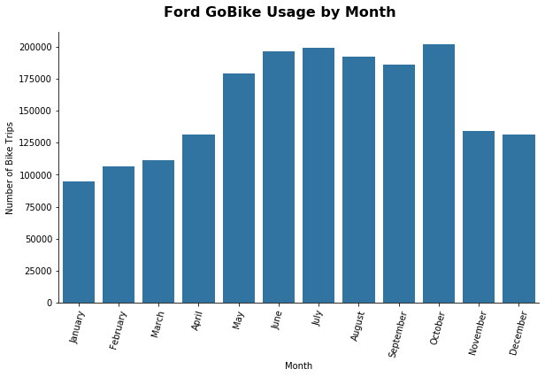

```python
# Monthly usage of the Ford Go Bike system
graph = sb.catplot(data = df_cleaned, x = 'start_time_month', kind = 'count', color = no_color, aspect = 1.7);

graph.set_axis_labels('Month', 'Number of Bike Trips'),

graph.fig.suptitle('Ford GoBike Usage by Month', y = 1.05, fontsize = 16, fontweight = 'bold');

graph.set_xticklabels(rotation=75);
```

###### Observation 1: Not surprisingly, the summer months and early-mid fall are the most popular times to use the Ford Go Bike sharing system. October is the most popular month, with July as the second most popular, and June/August coming in closely as the third most popular months to use the bike system. The weather in San Francisco is best in the mid-late summer and usually stays sunny until returning to its usual foggy weather in the late fall/early winter months.

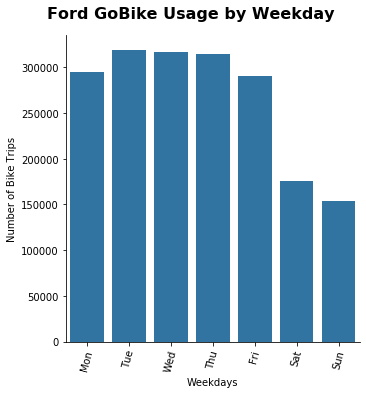

```python
# Weekday usage of the Ford Go bike system
weekday = ['Mon', 'Tue', 'Wed', 'Thu', 'Fri', 'Sat', 'Sun']

graph = sb.catplot(data=df_cleaned, x='start_time_weekday', kind='count', color = no_color, order = weekday)

graph.set_axis_labels('Weekdays', 'Number of Bike Trips')

graph.fig.suptitle('Ford GoBike Usage by Weekday', y=1.05, fontsize=16, fontweight='bold');

graph.set_xticklabels(rotation=75);
```

###### Observation 2: Tuesdays and Wednesdays seem to be the most popular days for using the bike sharing system, however Thursdays, Mondays and Fridays are very close to the Tues/Weds numbers. The usage drops significantly on Saturdays and Sundays suggesting the Ford bike share system is used primarily for commuting purposes during working days.

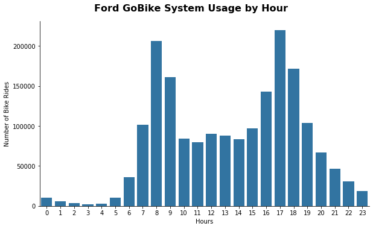

```python
# Hourly usage of the Ford Go Bike System
graph = sb.catplot(data = df_cleaned, x='start_time_hour', kind='count', color = no_color, aspect = 1.7)

graph.set_axis_labels('Hours', 'Number of Bike Rides')

graph.fig.suptitle('Ford GoBike System Usage by Hour', y=1.05, fontsize=16, fontweight='bold');
```

###### Observation 3: The bikes saw the most usage during the morning hours of 8-9am, and in the afternoon hours of 5-6pm, which is a typical workday in the United States. This furthers the suggestion that the bikes are being used primarily for commuters.

```python
df_cleaned.duration_min.describe()
```

```
count    1.863721e+06
mean     1.379682e+01
std      3.950700e+01
min      1.000000e+00
25%      5.000000e+00
50%      9.000000e+00
75%      1.400000e+01
max      1.439000e+03
Name: duration_min, dtype: float64
```

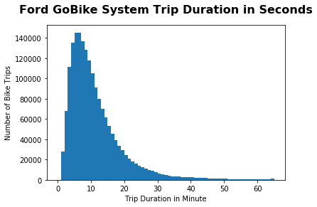

```python
# Duration of the bike rides - in SECONDS
bin_edges = np.arange(0, 66, 1)
ticks = np.arange(0, 66, 5)
plt.hist(data = df_cleaned, x = 'duration_min', bins = bin_edges);

plt.title("Ford GoBike System Trip Duration in Seconds", y=1.05, fontsize=16, fontweight='bold')
plt.xlabel('Trip Duration in Minute')
plt.ylabel('Number of Bike Trips');
```

###### Observation 4: It looks like 99% of the trips were less than 1 hour long with most of them fell between 5 to 10 minutes range. I'll remove the outlier long trips for this study to allow focusing on the most common cases to explore the pattern.

```python
# issue 8: filter out outlier trip records where the duration was very long
df_cleaned = df_cleaned.query('duration_min <= 66')
df_cleaned.info(null_counts=True)
```

```
<class 'pandas.core.frame.DataFrame'>
Int64Index: 1835980 entries, 6 to 1863720
Data columns (total 23 columns):
 #   Column                   Non-Null Count    Dtype
---  ------                   --------------    -----
 0   duration_sec             1835980 non-null  int64
 1   start_time               1835980 non-null  datetime64[ns]
 2   end_time                 1835980 non-null  datetime64[ns]
 3   start_station_id         1835980 non-null  object
 4   start_station_name       1824630 non-null  object
 5   start_station_latitude   1835980 non-null  float64
 6   start_station_longitude  1835980 non-null  float64
 7   end_station_id           1835980 non-null  object
 8   end_station_name         1824630 non-null  object
 9   end_station_latitude     1835980 non-null  float64
 10  end_station_longitude    1835980 non-null  float64
 11  bike_id                  1835980 non-null  object
 12  user_type                1835980 non-null  category
 13  bike_share_for_all_trip  1835980 non-null  category
 14  start_time_month         1835980 non-null  object
 15  start_time_month_num     1835980 non-null  int32
 16  start_time_weekday       1835980 non-null  object
 17  start_time_hour          1835980 non-null  int64
 18  end_time_hour            1835980 non-null  int64
 19  duration_min             1835980 non-null  int32
 20  start_date               1835980 non-null  object
 21  distance_km              1835980 non-null  float64
 22  distance_miles           1835980 non-null  float64
dtypes: category(2), datetime64[ns](2), float64(6), int32(2), int64(3), object(8)
memory usage: 297.7+ MB
```

```python
df_cleaned.duration_min.describe(percentiles = [.95])
df_cleaned.duration_min.describe()
```

```
count    1.835980e+06
mean     1.083398e+01
std      8.403833e+00
min      1.000000e+00
25%      5.000000e+00
50%      9.000000e+00
75%      1.400000e+01
max      6.600000e+01
Name: duration_min, dtype: float64
```

```python
df_cleaned.duration_min.mean()
```

```
10.833975315635247
```

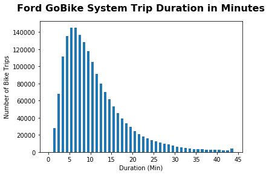

```python
# Duration of the bike rides -in MINUTES
bin_edges = np.arange(0, 45, 1)
ticks = [0, 5, 10, 15, 20, 25, 30,  35, 40, 45]
labels = ['{}'.format(val) for val in ticks]

plt.hist(data = df_cleaned, x = 'duration_min', bins = bin_edges, rwidth = 0.6);
#sb.distplot(df_cleaned['duration_min'], bins = bin_edges, kde = False, hist_kws = {'alpha' : 1});

plt.title("Ford GoBike System Trip Duration in Minutes", y=1.05, fontsize=16, fontweight='bold')
plt.xlabel('Duration (Min)')
plt.xticks(ticks, labels)
plt.ylabel('Number of Bike Trips');
```

```python
df_cleaned.distance_miles.describe()
```

```
count    1.835980e+06
mean     9.904250e-01
std      6.333291e-01
min      0.000000e+00
25%      5.439724e-01
50%      8.548518e-01
75%      1.297173e+00
max      1.194704e+01
Name: distance_miles, dtype: float64
```

```python
df_cleaned.distance_miles.mean()
```

```
0.9904250063801301
```

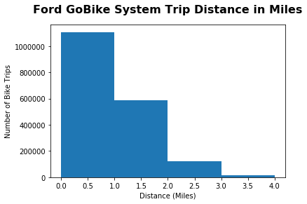

```python
# Distance in miles traveled
bin_edges = np.arange(0, 5, 1)

plt.hist(data = df_cleaned, x = 'distance_miles', bins = bin_edges);

plt.title("Ford GoBike System Trip Distance in Miles", y=1.05, fontsize=16, fontweight='bold')
plt.xlabel('Distance (Miles)')
plt.ylabel('Number of Bike Trips');
```

###### Observation 6: The mean distance traveled is 0.99 miles, with 75% of rides being 1.29 miles or less. Looking at the histogram above a majority of the rides fall under 2 miles, with over half of those 1 mile of less.

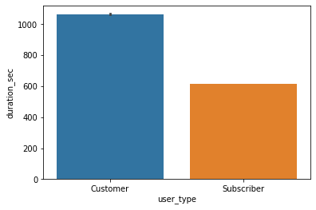

```python
#Total duration in seconds of usage of the bike sharing system by Customer and Subscriber (coding with seaborn)
sb.barplot(x='user_type', y='duration_sec', data=df_cleaned)
```

###### Observation 7: The above plot indicateds that the duration of usage of the bike sharing system were more by customers than the members.

```python
#Most commonly used start_station, which start_station has high demand
df_cleaned.start_station_id.value_counts(sort=True)
```

```
67.0     37457
15.0     36693
30.0     34870
58.0     34564
81.0     33524
         ...
359.0       87
301.0       85
358.0       52
374.0       17
48.0        11
Name: start_station_id, Length: 332, dtype: int64
```

```python
df_max_station = df_cleaned[df_cleaned.start_station_id == '15.0']
```

```python
df_max_station
```

|  | duration_sec | start_time | end_time | start_station_id | start_station_name | start_station_latitude | start_station_longitude | end_station_id | end_station_name | end_station_latitude | ... | bike_share_for_all_trip | start_time_month | start_time_month_num | start_time_weekday | start_time_hour | end_time_hour | duration_min | start_date | distance_km | distance_miles |
| --- | --- | --- | --- | --- | --- | --- | --- | --- | --- | --- | --- | --- | --- | --- | --- | --- | --- | --- | --- | --- | --- |
| 30 | 375 | 2018-01-31 22:56:31.082 | 2018-01-31 23:02:46.583 | 15.0 | San Francisco Ferry Building (Harry Bridges Pl... | 37.795392 | -122.394203 | 6.0 | The Embarcadero at Sansome St | 37.804770 | ... | No | January | 1 | Wed | 22 | 23 | 6 | 2018-01-31 | 1.310345 | 0.814210 |
| 90 | 451 | 2018-01-31 21:57:35.425 | 2018-01-31 22:05:07.018 | 15.0 | San Francisco Ferry Building (Harry Bridges Pl... | 37.795392 | -122.394203 | 6.0 | The Embarcadero at Sansome St | 37.804770 | ... | No | January | 1 | Wed | 21 | 22 | 7 | 2018-01-31 | 1.310345 | 0.814210 |
| 141 | 841 | 2018-01-31 21:25:01.905 | 2018-01-31 21:39:03.712 | 15.0 | San Francisco Ferry Building (Harry Bridges Pl... | 37.795392 | -122.394203 | 58.0 | Market St at 10th St | 37.776619 | ... | No | January | 1 | Wed | 21 | 21 | 14 | 2018-01-31 | 2.916783 | 1.812404 |
| 207 | 511 | 2018-01-31 21:01:37.141 | 2018-01-31 21:10:08.258 | 15.0 | San Francisco Ferry Building (Harry Bridges Pl... | 37.795392 | -122.394203 | 81.0 | Berry St at 4th St | 37.775880 | ... | No | January | 1 | Wed | 21 | 21 | 8 | 2018-01-31 | 2.171534 | 1.349328 |
| 368 | 891 | 2018-01-31 20:00:20.046 | 2018-01-31 20:15:11.682 | 15.0 | San Francisco Ferry Building (Harry Bridges Pl... | 37.795392 | -122.394203 | 81.0 | Berry St at 4th St | 37.775880 | ... | No | January | 1 | Wed | 20 | 20 | 14 | 2018-01-31 | 2.171534 | 1.349328 |
| ... | ... | ... | ... | ... | ... | ... | ... | ... | ... | ... | ... | ... | ... | ... | ... | ... | ... | ... | ... | ... | ... |
| 1863408 | 646 | 2018-12-01 09:53:28.241 | 2018-12-01 10:04:14.959 | 15.0 | San Francisco Ferry Building (Harry Bridges Pl... | 37.795392 | -122.394203 | 6.0 | The Embarcadero at Sansome St | 37.804770 | ... | No | December | 12 | Sat | 9 | 10 | 10 | 2018-12-01 | 1.310345 | 0.814210 |
| 1863504 | 369 | 2018-12-01 08:44:23.469 | 2018-12-01 08:50:33.300 | 15.0 | San Francisco Ferry Building (Harry Bridges Pl... | 37.795392 | -122.394203 | 6.0 | The Embarcadero at Sansome St | 37.804770 | ... | No | December | 12 | Sat | 8 | 8 | 6 | 2018-12-01 | 1.310345 | 0.814210 |
| 1863528 | 471 | 2018-12-01 08:24:44.547 | 2018-12-01 08:32:36.223 | 15.0 | San Francisco Ferry Building (Harry Bridges Pl... | 37.795392 | -122.394203 | 50.0 | 2nd St at Townsend St | 37.780526 | ... | No | December | 12 | Sat | 8 | 8 | 7 | 2018-12-01 | 1.688445 | 1.049151 |
| 1863556 | 2644 | 2018-12-01 07:23:10.895 | 2018-12-01 08:07:15.015 | 15.0 | San Francisco Ferry Building (Harry Bridges Pl... | 37.795392 | -122.394203 | 23.0 | The Embarcadero at Steuart St | 37.791464 | ... | No | December | 12 | Sat | 7 | 8 | 44 | 2018-12-01 | 0.517986 | 0.321862 |
| 1863708 | 681 | 2018-12-01 00:19:41.383 | 2018-12-01 00:31:02.605 | 15.0 | San Francisco Ferry Building (Harry Bridges Pl... | 37.795392 | -122.394203 | 323.0 | Broadway at Kearny | 37.798014 | ... | No | December | 12 | Sat | 0 | 0 | 11 | 2018-12-01 | 1.072565 | 0.666461 |

36693 rows × 23 columns

#### Discuss the distribution(s) of your variable(s) of interest. Were there any unusual points? Did you need to perform any transformations?

The number of trips peaked around 8-9am and 17-18pm during a day, there were more trips on work days (Mon-Fri) compared to weekends. Summar time was the most popular season of a year, likely due to the weather.

Most rides were quick and short, lasted between 5 to 10 minutes, though there were some very long outliers like 24hrs.

Thankfully, due to thorough cleaning efforts there were no big surprises during the exploratory and visualization phase. The duration of the bike ride and the distance gave me a little trouble since there were some outliers I didn't anticipate.

#### Of the features you investigated, were there any unusual distributions? Did you perform any operations on the data to tidy, adjust, or change the form of the data? If so, why did you do this?

The distribution of the trip duration was a little surprising at first plotting out the original data. Used .describe() and xticks() to zoom in to a smaller range where most trip records fell, which made the distribution much clearer. In order to help focusing on the main cases of typical use of the system, I filtered out the outlier long trip records for the study with .query().

## Bivariate Exploration

In this section, I investigate relationships between pairs of variables in the data.

```python
all_numeric_vars = ['duration_sec', 'start_time', 'end_time', 'start_station_id', 'start_station_latitude', 'start_station_longitude', 'end_station_id', 'end_station_latitude',
'end_station_longitude', 'bike_id', 'duration_min']
numeric_vars = ['duration_min']
categoric_vars = ['start_time_dayofweek', 'start_time_hour', 'user_type']
```

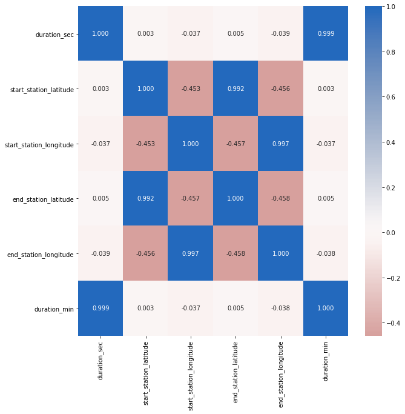

```python
# correlation plot
plt.figure(figsize = [10, 10])

sb.heatmap(df_cleaned[all_numeric_vars].corr(), annot = True, fmt = '.3f', cmap = 'vlag_r', center = 0);
```

```python
# Customers vs Subscribers
customer = df_cleaned.query('user_type == "Customer"')['bike_id'].count()
subscriber = df_cleaned.query('user_type == "Subscriber"')['bike_id'].count()
customer_prop = customer / df_cleaned['bike_id'].count()
subscriber_prop = subscriber / df_cleaned['bike_id'].count()
```

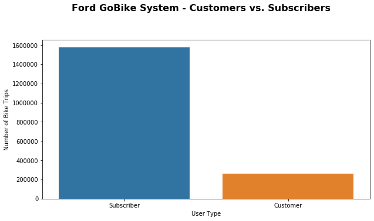

```python
# Customers vs Subscribers Visuals
# bar chart
plt.figure(figsize = [10, 5])

graph = sb.countplot(data = df_cleaned, x = "user_type", order = df_cleaned.user_type.value_counts().index);
graph.set_xlabel('User Type');
graph.set_ylabel('Number of Bike Trips');
plt.suptitle('Ford GoBike System - Customers vs. Subscribers', y=1.05, fontsize=16, fontweight='bold');
```

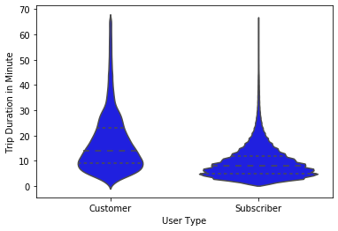

```python
#How does the trip duration distribution vary between customers and subscribers?
sb.violinplot(data=df_cleaned, x='user_type', y='duration_min', color= 'blue', inner='quartile');
plt.xlabel('User Type');
plt.ylabel('Trip Duration in Minute');
```

###### Observation 2: The trip duration distribution is much narrower for subscribers compared to casual riders on the shorter/quicker trip end overall. It seems like subscribers have a more specific usage or targeted goal riding the bikes compared to customers who vary more and generally rented the bikes for longer.

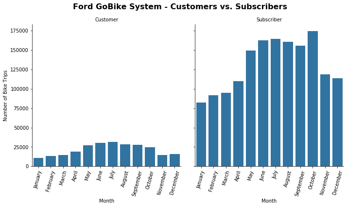

```python
# Customer Usage by Month vs. Subscriber Usage by Month
#plt.figure(figsize = [12, 5])
graph = sb.catplot(data=df_cleaned, x='start_time_month', col="user_type", kind='count', sharey = True, color = no_color);

graph.set_axis_labels("Month", "Number of Bike Trips");
graph.set_titles("{col_name}");

graph.fig.suptitle('Ford GoBike System - Customers vs. Subscribers', y=1.05, fontsize=16, fontweight='bold');
graph.set_xticklabels(rotation=75);
```

###### Observation 3: Winter months are the worst for the bike sharing system for both groups what can be determined by the harsher weather.

Customers: demand is high around summertime, reaching its peak in July. Customers are most probably tourists, or the occasional riders who visit the Bay Area. Subscribers: the highest demand is from May till October, reaching it's peak in October. Subscribers are most likely riders using the bikes for their daily commute.

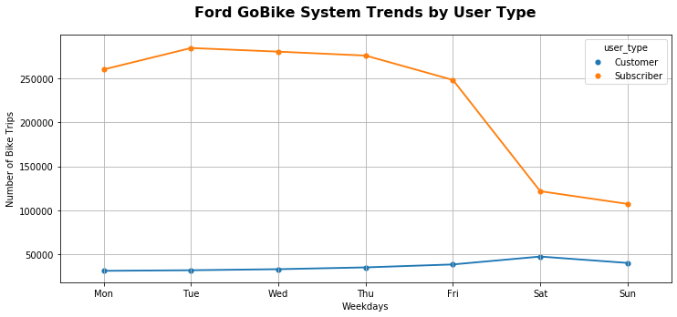

```python
# Customer Usage by Weekday vs. Subscriber Usage by Weekday
plt.figure(figsize=(12, 5))

df_cleaned_user_week = df_cleaned.groupby(['start_time_weekday', 'user_type']).size().reset_index()
weekday = ['Mon', 'Tue', 'Wed', 'Thu', 'Fri', 'Sat', 'Sun']

ax = sb.pointplot(data=df_cleaned_user_week, x='start_time_weekday', y=0, hue = 'user_type', scale=.7, order = weekday);

plt.title('Ford GoBike System Trends by User Type', y=1.05, fontsize=16, fontweight='bold')
plt.xlabel('Weekdays')
plt.ylabel('Number of Bike Trips');
plt.grid()
```

###### Observation 4: There was much more subscriber usage than casual customers overall. The drop of volume on weekends for subscribers indicates that they primarily ride bikes for work commute during work days, whereas almost the opposite pattern of a slight increase of use for customers on weekends demonstrates that the use was more for leisure/touring and relaxing purposes.

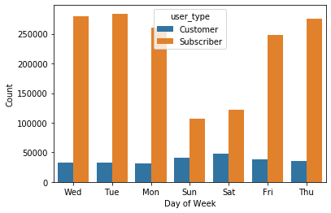

```python
#Weekly usage between customers and subscribers

sb.countplot(data=df_cleaned, x='start_time_weekday', hue='user_type');
plt.xlabel('Day of Week');
plt.ylabel('Count');
```

###### Observation 5: The point plot above is an excellent visual showing the sharp contrast between Customers and Subscribers. Customers have a relatively low usage of the bike share system with a small increase on the weekends. Subscribers are the opposite - there is steadily high usage on weekdays, with a sharp decline on the weekend.

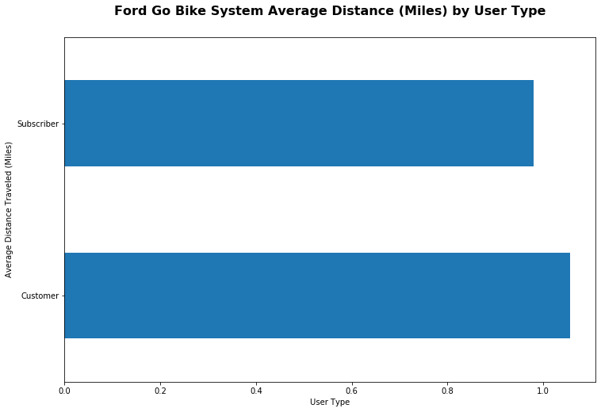

```python
# Customer Usage by Distance vs. Subscriber Usage by Distance
plt = df_cleaned.groupby('user_type')['distance_miles'].mean().plot(kind='barh', figsize=(12,8));

plt.set_title('Ford Go Bike System Average Distance (Miles) by User Type', y=1.05, fontsize=16, fontweight='bold')
plt.set_xlabel('User Type')
plt.set_ylabel('Average Distance Traveled (Miles)');
```

###### Observation 6: The average distance traveled by customers is slightly higher than subscribers. Since the data exploration thus far suggests subscribers are using the bike share system for commuting purposes, that suggestion also implies that the commuting distance for the subscribers is less than the average ride a customer takes

```python
df_cleaned.duration_min.describe(percentiles = [.95])
```

```
count    1.835980e+06
mean     1.083398e+01
std      8.403833e+00
min      1.000000e+00
50%      9.000000e+00
95%      2.700000e+01
max      6.600000e+01
Name: duration_min, dtype: float64
```

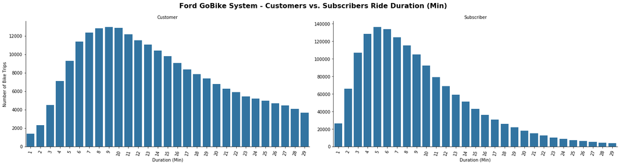

```python
# Customer Usage by Duration vs. Subscriber Usage by Duration

data = df_cleaned.query('duration_min < 30')

graph = sb.catplot(data=data, x = 'duration_min', col='user_type', kind='count', sharey = False, color = no_color, height=5, aspect=2);

graph.set_axis_labels('Duration (Min)', 'Number of Bike Trips')
graph.set_titles('{col_name}')

graph.fig.suptitle('Ford GoBike System - Customers vs. Subscribers Ride Duration (Min)', y=1.05, fontsize=16, fontweight='bold');
graph.set_xticklabels(rotation=75);
```

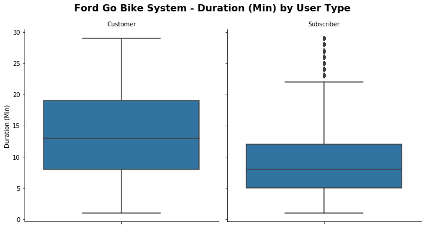

```python
data = df_cleaned.query('duration_min < 30')

g = sb.catplot(data=data, y='duration_min', col="user_type", kind='box', color = no_color)

g.set_titles(col_template = '{col_name}')
g.set_axis_labels("", "Duration (Min)")
g.fig.suptitle('Ford Go Bike System - Duration (Min) by User Type', y=1.05, fontsize=16, fontweight='bold');
```

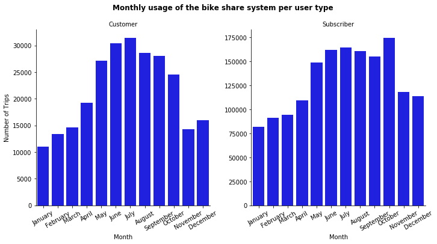

```python
# Analysis of the number of trips taken by different user types across months in a year

graph= sb.catplot(data=df_cleaned, x='start_time_month', col="user_type", kind='count', sharey = False, color= 'blue')
graph.set_axis_labels("Month", "Number of Trips")
graph.set_titles("{col_name}")
graph.fig.suptitle('Monthly usage of the bike share system per user type', y=1.05, fontsize=12, fontweight='semibold')
graph.set_xticklabels(rotation=30);
```

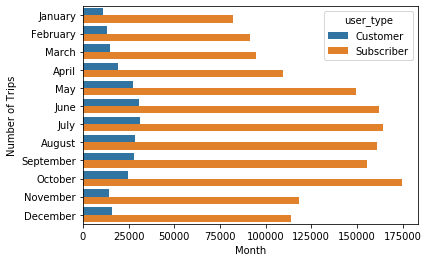

```python
ax= sb.countplot(data=df_cleaned, y='start_time_month', hue='user_type');
ax.set_xlabel('Month');
ax.set_ylabel('Number of Trips');
```

Both subscribers and customers ride the most during the summer months with subscribers maxed out in October and customers peaked in July. The usage was clearly not popular during winter season like November, December and January likely due to the weather.

#### Talk about some of the relationships you observed in this part of the investigation. How did the feature(s) of interest vary with other features in the dataset?

Adding the user type to the analysis revealed different behavior usage between customers and subscribers. The data suggests that customers are casual riders such as tourists, or students on a school vacation or holiday. This is accurate when factoring in that Customer that tend to ride for fun in the afternoon or early evenings over weekends and peaks during the month of July. In contrast, the data suggests Subscribers are daily commuters or full time students who use the system during weekdays, better weather, and mostly for shorter distances. They mainly rent bikes before and after a typical work or school day (8-9am and 5-6pm).

#### Did you observe any interesting relationships between the other features (not the main feature(s) of interest)?

There is a difference in the trip duration between customers and subscribers. Customers trips are usually longer than for subscribers, most probably due to the fact they prefer bike rides around weekends in summertime, which may be for longer trips around the surrounding area. Subscribers use the system mainly for commute purposes so they prefer quick, short rides to and from work.

## Multivariate Exploration

I created plots of three or more variables to investigate the Ford Go Bike data even further.

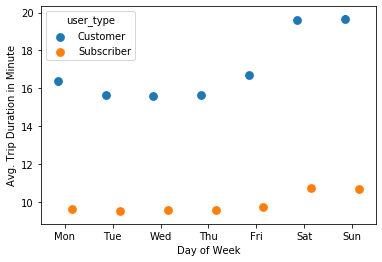

```python
#How does the average trip duration vary in weekdays between customers and subscribers?
plt=sb.pointplot(data=df_cleaned, x='start_time_weekday', y='duration_min', hue='user_type', dodge=0.3, linestyles="");
plt.set_xlabel('Day of Week');
plt.set_ylabel('Avg. Trip Duration in Minute');
```

###### Observation 1: It can be seen from the above plot that subscribers ride much shorter/quicker trips compared to customers on each day of the week. Both user types have an obvious increase of trip duration on Saturdays and Sundays over weekends, especially for casual riders. Subscribers usage seems to be more efficient than customers overall and maintained a very consistent average duration Monday through Friday.

```python
plt.suptitle('Hourly Usage during Weekdays for Customers and Subscribers')

plt.subplot(2, 1, 1)
customers = df_cleaned.query('user_type == "Customer"')
ct_counts = customers.groupby(['start_time_weekday', 'start_time_hour']).size()
ct_counts = ct_counts.reset_index(name='count')
ct_counts = ct_counts.pivot(index='start_time_weekday', columns='start_time_hour', values='count')
heatmap= sb.heatmap(ct_counts, cmap='rocket_r');
heatmap.set_title('Customer', loc='right');
heatmap.set_xlabel('Hour of Day');
heatmap.set_ylabel('Day of Week');

plt.subplot(2, 1, 2)
subscribers = df_cleaned.query('user_type == "Subscriber"')
st_counts = subscribers.groupby(['start_time_weekday', 'start_time_hour']).size()
st_counts = st_counts.reset_index(name='count')
st_counts = st_counts.pivot(index='start_time_weekday', columns='start_time_hour', values='count')
sb.heatmap(st_counts, cmap='rocket_r');
heatmap.set_title('Subscriber', loc='right');
heatmap.set_xlabel('Hour of Day');
heatmap.set_ylabel('Day of Week');
```

[output not shown]

###### Please reference the slide deck with the correct visual - after much trial and error I can not get the code to work properly in this notebook.

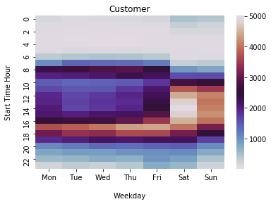

```python
# Weekday order
weekday = ['Mon', 'Tue', 'Wed', 'Thu', 'Fri', 'Sat', 'Sun']
df_cleaned['start_time_weekday'] = pd.Categorical(df_cleaned['start_time_weekday'], categories= ['Mon', 'Tue', 'Wed', 'Thu', 'Fri', 'Sat', 'Sun'], ordered=True);

#plt.figure(figsize=(15,8))

# Heatmap - Customers
#plt.subplot(1, 2, 1)
df_customer = df_cleaned.query('user_type == "Customer"').groupby(['start_time_hour', 'start_time_weekday'])['bike_id'].size().reset_index();
df_customer = df_customer.pivot('start_time_hour', 'start_time_weekday', 'bike_id')

heat_map = sb.heatmap(df_customer, cmap = 'twilight')

heat_map.set_title('Customer', y=1.05)
heat_map.set_xlabel('Weekday', labelpad = 16)
heat_map.set_ylabel('Start Time Hour',  labelpad = 16)


#graph.suptitle('Ford GoBike System - Start Time vs. Weekday by User Type', y = 1.05, fontsize = 16, fontweight = 'bold');
```

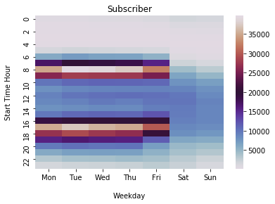

```python
# Heatmap - Subscribers
#plt.subplot(1, 2, 2)
df_subscriber = df_cleaned.query('user_type == "Subscriber"').groupby(['start_time_hour', 'start_time_weekday'])['bike_id'].size().reset_index();
df_subscriber = df_subscriber.pivot('start_time_hour', 'start_time_weekday', 'bike_id')
heat_map = sb.heatmap(df_subscriber, cmap = 'twilight')

heat_map.set_title("Subscriber", y=1.05)
heat_map.set_xlabel('Weekday', labelpad = 16)
heat_map.set_ylabel('Start Time Hour', labelpad = 16);
```

#### Talk about some of the relationships you observed in this part of the investigation. Were there features that strengthened each other in terms of looking at your feature(s) of interest?

The multivariate exploration strengthened some of the patterns discovered in the previous bivariate exploration as well as univariate exploration, the relationship between the multiple variables plotted are visualized altogether and information are presented combined. There are a lot more subscriber usage than customers. The riding habit/pattern varies a lot between subscribers and customers.

The efficient/short period of usage for subscribers corresponds to their high concentration on rush hours Monday through Friday, indicating the use is primarily for work commute. The more relaxing and flexible pattern of customer use shows that they're taking advantage of the bike sharing system quite differently from the subscribers, heavily over weekends and in the afternoon, for city tour or leisure purpose probably.

#### Were there any interesting or surprising interactions between features?

The interactions between features are all supplementing each other and quite make sense when looked at combined, there's no big surprise observed.

## Summary

This project is a win - win situation where a large number of people can benefit from this program:

- Environmentally friendly, budget friendly, and lifetsyle friendly.
- Subscribers (i.e. daily commuters) benefit from a health commuting choice
- Customers (i.e. tourists, students, etc.) have a sustainable, yet flexible option for touring the city.
- Affordable and convenient transportation for the people of all socioeconomic classes

Renting a bike from theFord GoBike System is a fantastic (healthy and environmentally friendly) way of moving around in the city, both for enjoyment and work. There are two types of clients using the system: Subscribers and Customers. Subscribers are primarily daily commuters, having short trips to and from work, who rent a bike on weekdays at 8-9am and 5-6pm, and, occasionally around lunch time. Customers are usually tourists or occassional riders who use the system mainly on weekends to explore the Bay Area.

## Sources

- FordGoBike Data Set
- Haversine formula used to calculate distances using latitude and longitude
- Seaborn catplot documentation
- Matplotlib histogram documentation
- IPython Display documentation
- Seaborn heatmap documentation and tutorial